# Week 1

# Basic Business Statistics in R

In my interactions with business professionals who use R, I have frequently heard the importance of reviewing the statistical fundamentals that drive decision-making in the workplace. The purpose of this notebook is to review the most fundamental elements of statistically sound decision making using a typical business dataset. In this notebook, regressions and tests for significance are reviewed.

## Load Packages and Necessary Data

```r
df %>% write_csv("/data/full_data.csv")
```

[output not shown]

# Test for a true difference between means

One challenge of business decision making is determining whether an observation represents a true picture of the world. Since we can never account for every single factor in a model, all models are imperfect and wrong (though many are still useful). Examples of this problem arise when managers must decide whether a there is a true difference in performance between sales staff, departments, or regions. How much of a difference is enough to conclude that one store is performing better than another?

To conceptualize the problem, I consider playing disc golf with my wife. If I watch one player beat another by one stroke over 18 holes, I would not feel confident to conclude that she is better than her peer (it woudl seem plausible that the difference could just be luck). However, is she beat her peer by 15 strokes in one game, I would feel pretty confident that she is better. Alternatively, if she beat her peer by one stroke every single time over 150 games, I would feel pretty confident that she is marginally better. Our confidence that there is a difference in performance between two players can increase with either a bigger difference in performance or a greater number of observations.

In the same way, we can compare the sales performance of several stores in this dataset. If one store sells 10M dollars in product in one week, but another sells 10,000,001 dollars, would you believe that the second store is better than the first? In this data set we can look at the average weekly sales of each store and see that Store #20 outperforms Store #4, while both outperform Store #39. However, this does not take into account the natural variation in each week’s sales. The challenge then is to use the Welch’s Studentized T-test to see if there is a true difference between means.

For the first challenge, we will compare stores #20, #4, and #39. Stores #20 and #4 are ranked #1 and #2 in average weekly sales (out of 45 total stores) while store #39 is ranked #10. Does store #20 perform better than store #4? Does store #20 perform better than store #39?

```r
#Rank stores to see how weekly averages compare
df %>%
  select(Weekly_Sales, Store) %>%
  group_by(Store) %>%
  summarise(avg = mean(Weekly_Sales)) %>%
  arrange(-avg) %>%
  mutate(rank = rank(-avg))
```

| Store | avg | rank |
| --- | --- | --- |
| 20 | 29508.302 | 1 |
| 4 | 29161.210 | 2 |
| 14 | 28784.852 | 3 |
| 13 | 27355.137 | 4 |
| 2 | 26898.070 | 5 |
| 10 | 26332.304 | 6 |
| 27 | 24826.985 | 7 |
| 6 | 21913.244 | 8 |
| 1 | 21710.544 | 9 |
| 39 | 21000.764 | 10 |

[output cut: 35 more lines]

## Is there a true difference between the average weekly sales of Store 20 and Store 4? Compare the distributions and visualize the difference.

```r
#Does store 20 perform better than store 4 on average?
store_20_sales <- df %>%
  filter(Store == 20) %>%
  select(Weekly_Sales) %>%
  unlist
store_4_sales <- df %>%
  filter(Store == 4) %>%
  select(Weekly_Sales) %>%
  unlist
twenty_vs_four <- stats::t.test(store_20_sales, store_4_sales, conf.level = .95)
twenty_vs_four
```

```
    Welch Two Sample t-test

data:  store_20_sales and store_4_sales
t = 0.7071, df = 20457, p-value = 0.4795
alternative hypothesis: true difference in means is not equal to 0
95 percent confidence interval:
 -615.0385 1309.2209
sample estimates:
mean of x mean of y
 29508.30  29161.21
```

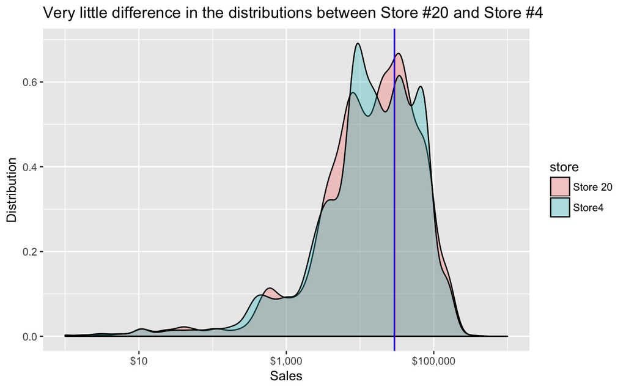

```r
#Distributions of store 20 and store 4
data_frame(sales = store_20_sales, store = "Store 20") %>%
  bind_rows(data_frame(sales = store_4_sales, store = "Store4")) %>%
  ggplot(aes(sales, fill = store)) +
    geom_density(alpha = .3) +
    scale_x_log10(limits = c(1, 1000000), labels = dollar) +
    geom_vline(xintercept = mean(store_20_sales), color = "red") +
    geom_vline(xintercept = mean(store_4_sales), color = "blue") +
    labs(title = "Very little difference in the distributions between Store #20 and Store #4",
         x = "Sales",
         y = "Distribution")
```

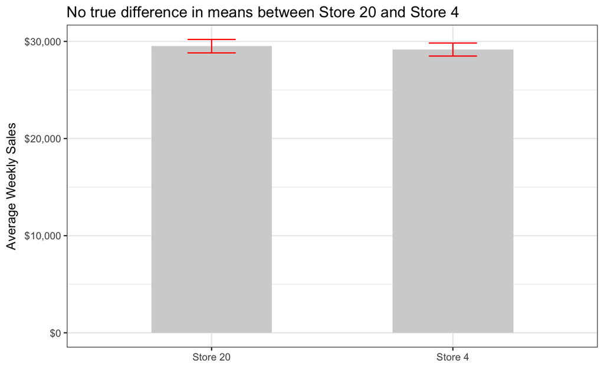

```r
#Visualize difference in means w/errorbars for store 20 and store 4
mean_cl_normal(store_20_sales) %>%
  bind_rows(mean_cl_normal(store_4_sales)) %>%
  mutate(store = c("store_20", "store_4")) %>%
  ggplot(aes(x = store, y = y)) +
    geom_bar(stat = "identity", fill = "lightgray", width = .5) +
    geom_errorbar(aes(ymin = ymin, ymax = ymax), width = .2, color = "red") +
    labs(title = "No true difference in means between Store 20 and Store 4",
         x = element_blank(),
         y = "Average Weekly Sales") +
    scale_x_discrete(labels = c("Store 20", "Store 4")) +
    scale_y_continuous(labels = scales::dollar) +
    theme_bw()
```